# Effects of Loan Amount and Prosper Ratings on Borrower's Annual Percentage Rate.

## by Rachael Olakunmi Ogunye

## Investigation Overview

> In this investigation, I wanted to look at how Loan amounts and Prosper ratings can be used to predict the Borrower's APR.

## Dataset Overview

> There were 113,937 entries in the main dataset with 81 features from which the subset dataset (df_loan) was extracted, assessed and cleaned to produce the 'CleanedLoanData' consisting of 83982 loan entries with 21 features (including LoanOriginalAmount, BorrowerAPR, StatedMonthlyIncome, ProsperRating (Alpha), EmploymentStatus and many others).

## Distribution of Borrower Annual Percentage Rate (APR)

> The BorrowerAPR is the annual cost of a loan to a borrower.

> The distribution is a normal multimodal distribution with small peaks around 0.1, 0.2 and 0.3. There is a very shape peak between 0.35 and 0.36. Only very few loans have APR greater than 0.43. BorrowerAPR is the main variable of interest.

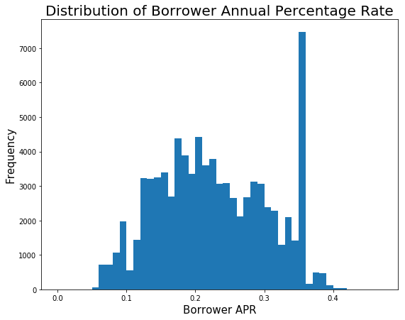

## Distribution of Loan amount

> LoanOriginalAmount: The origination amount of the loan.

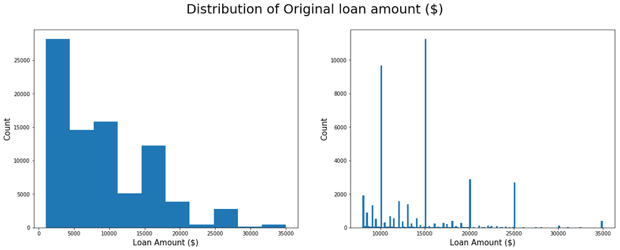

## Distribution of Prosper Ratings

> ProsperRating (Alpha): The Prosper Rating assigned at the time the listing was created between AA - HR.

> The ratings of most of the borrowers are among A to D with C being the highest rating.

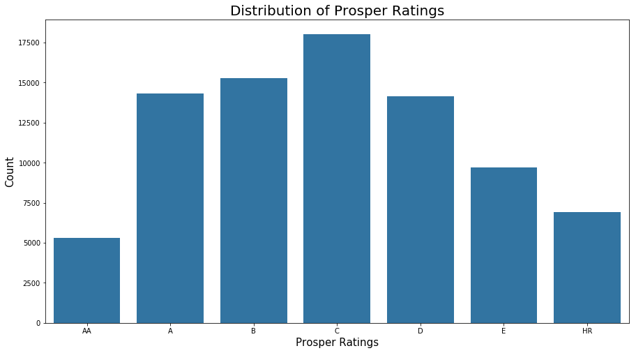

## Relationship between BorrowerAPR and Loan Amount

> This plot shows that at different loan amounts, the APR has a wide range, but the range of APR decreases with increasing loan amount. The plot shows that the borrowerAPR is negatively correlated with loan amount.

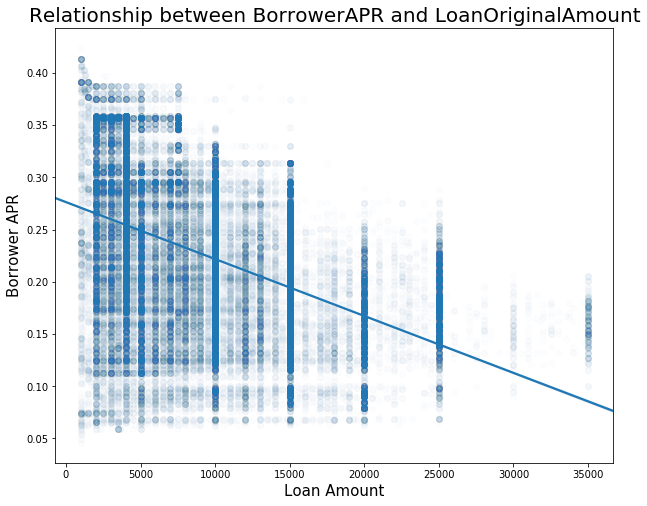

## Relationship between BorrowerAPR and Prosper Ratings

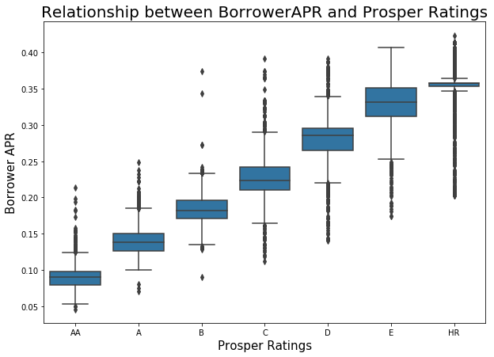

## Relationship between BorrowerAPR, Prosper Ratings and Loan Amount

> The loan amount decreases with increasing Prosper rating while the borrower's APR increases with increasing Prosper rating. Interestingly, the relationship between borrower APR and loan amount turns from slightly positive to negative when the Prosper ratings are increased from AA to HR.

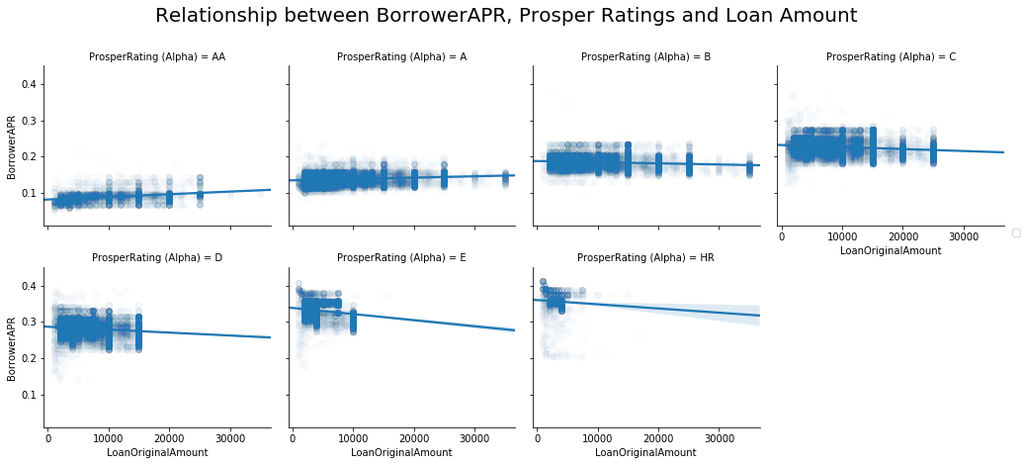

## Conclusion

> BorrowerAPR decreases with increasing loan amount (negatively correlated).